In my [last post](http://hopstat.wordpress.com/2014/10/16/ggplot2-is-not-always-the_answer-its-not-supposed-to-be-7/), I discussed how `ggplot2` is not always the answer to the question “How should I plot this” and that base graphics were still very useful.

# Why Do I use ggplot2 then?

The overall question still remains: why (do I) use `ggplot2`?

## ggplot2 vs lattice

For one, `ggplot2` replaced the `lattice` package for many plot types for me. The `lattice` package is a great system, but if you are plotting multivariate data, I believe you should choose `lattice` or `ggplot2`. I chose `ggplot2` for the syntax, added capabilities, and the philosophy behind it. The fact [Hadley Wickham](http://had.co.nz/) is the developer never hurts either.

## Having multiple versions of the same plot, with slight changes

Many times I want to do the same plot over and over, but vary one aspect of it, such as color of the points by a grouping variable, and then switch the color to another grouping variable. Let me give a toy example, where we have an `x` and a `y` with two grouping variables: `group1` and `group2`.

We can construct the `ggplot2` object as follows:

The `ggplot` command takes the `data.frame` you want to use and use the `aes` to specificy which aesthetics we want to specify, here we specify the `x` and `y`. Some aesthetics are optional depending on the plot, some are not. I think it's safe to say you always need an `x`. I then “add” (using `+`) to this object a “layer”: I want a geometric “thing”, and that thing are points, hence I use `geom_points`. I'm doing a scatterplot.

If you just call the object `g`, `print` is called by default, which plots the object and we see our scatterplot.

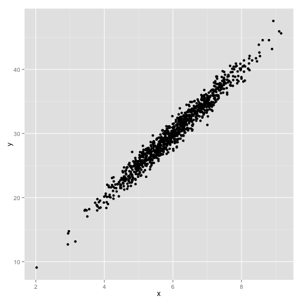

I can color by a grouping variable and we can add that aesthetic:

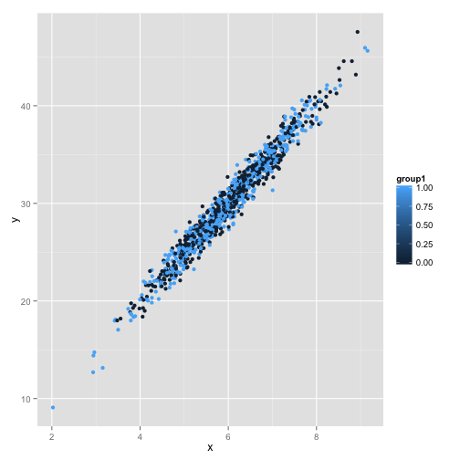

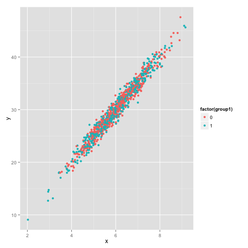

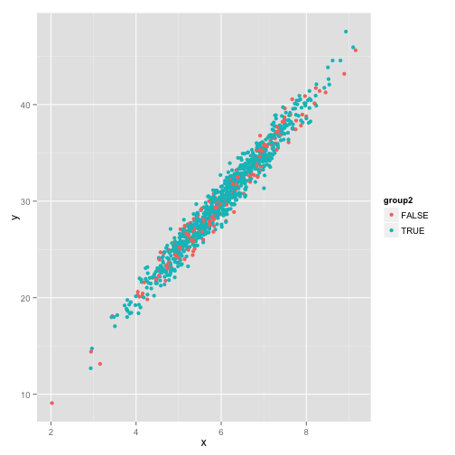

Note, `g` is the original plot, and I can add `aes` to this plot, which is the same as if I did `ggplot2(data, aes(...))` in the original call that generated `g`. **NOTE** if the `aes` you are adding was not a column of the `data.frame` when you created the plot, you will get an error. For example, let's add a new column to the data and then add it to `g`:

```
Error: object 'newcol' not found
```

This fails because the way the `ggplot2` object was created. If we had added this column to the data, created the plot, then added the `newcol` as an `aes`, the command would work fine.

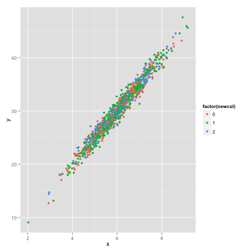

We see in the first plot with `colour = group1`, `ggplot2` sees a numeric variable `group1`, so tries a continuous mapping scheme for the color. The default is to do a range of blue colors denoting intensity. If we want to force it to a discrete mapping, we can turn it into a factor `colour = factor(group1)`. We see the colors are very different and are not a continuum of blue, but colors that separate groups better.  
The third plot illustrates that when `ggplot2` takes logical vectors for mappings, it factors them, and maps the group to a discrete color.

### Slight Changes with additions

In practice, I do this iterative process many times and the addition of elements to a common template plot is very helpful for speed and reproducing the same plot with minor tweaks.

In addition to doing similar plots with slight grouping changes I also add different lines/fits on top of that. In the previous example, we colored by points by different grouping variables. In other examples, I tend to change little things, e.g. a different smoother, a different subset of points, constraining the values to a certain range, etc. I believe in this way, `ggplot2` allows us to create plots in an more structured way, without copying and pasting the entire command or creating a user-written wrapper function as you would in base. This should increase reproducibility by decreasing copy-and-paste errors. I tend to have many copy-paste errors, so I want to limit them as much as possible.

## ggplot reduces number of commands I have to do

One example plot I make frequently is a scatterplot with a smoother to estimate the shape of bivariate data.

In base, I usually have to run at least 3 commands to do this, e.g. `loess`, `plot`, and `lines`. In `ggplot2`, `geom_smooth()` takes care of this for you. Moreover, it does the smoothing by each different aesthetics (aka smoothing per group), which is usually what I want do as well (and takes more than 3 lines in base, usually a `for` loop or `apply` statement).

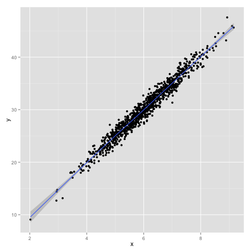

By default in `geom_smooth`, it includes the standard error of the estimated relationship, but I usually only look at the estimate for a rough sketch of the relationship. Moreover, if the data are correlated (such as in longitudinal data), the standard errors given by default methods are ususally are not accurate anyway.

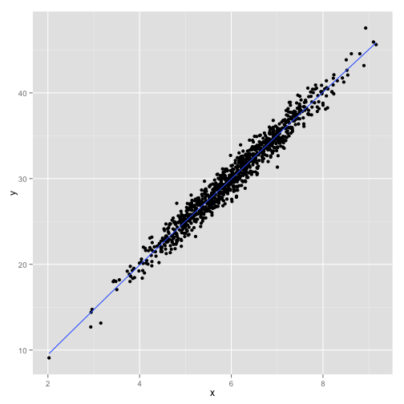

Therefore, on top of the lack of copying and pasting, you can reduce the number of lines of code. Some say “but I can make a function that does that” – yes you can. Or you can use the commands already there in `ggplot2`.

### Faceting

The other reason I frequently use `ggplot2` is for faceting. You can do the same graph, conditioned on levels of a variable, which I frequently used. Many times you want to do a graph, subset by another variable, such as treatment/control, male/female, cancer/control, etc.

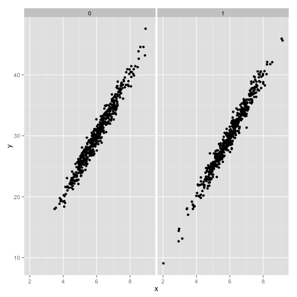

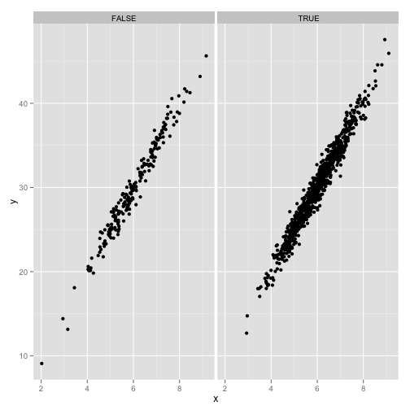

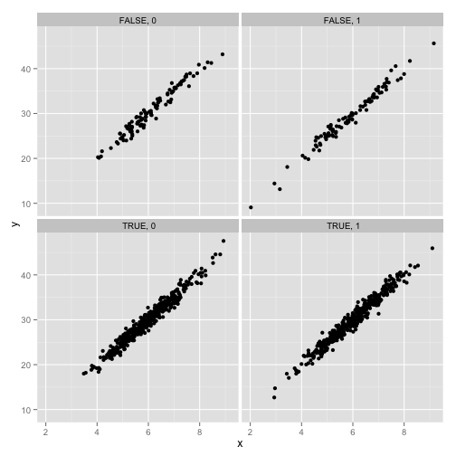

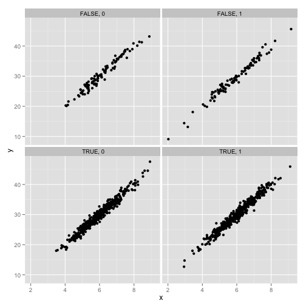

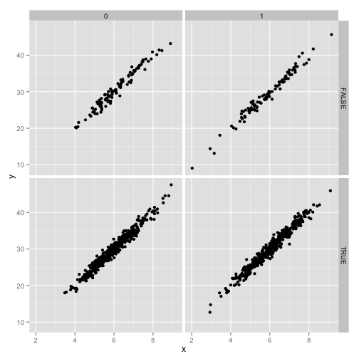

## Spaghetti plot with Overall smoother

I also frequently have longitudinal data and make spaghetti plot for a per-person trajectory over time.  
For this example I took code from [StackOverflow](http://stats.stackexchange.com/questions/76999/simulating-longitudinal-lognormal-data-in-r) to create some longitudinal data.

I will first add an alpha level to the plotting lines for the next plot (remember this must be done before the original plot is created). `tspag` will be the template plot, and I will create a spaghetti plot (`spag`) where each colour represents an `id`:

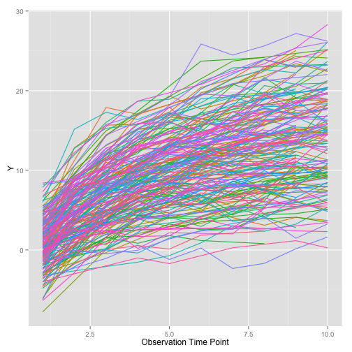

Many other times I want to group by `id` but plot just a few lines (let's say 10% of them) dark and the other light, and not colour them:

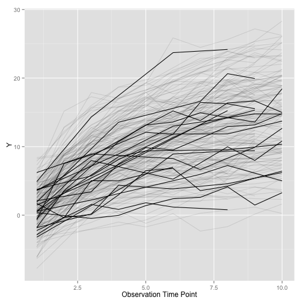

Overall, these 2 plots are useful when you have longitudinal data and don't want to loop over ids or use `lattice`. The great addition is that all the facetting and such above can be used in conjuction with these plots to get spaghetti plots by subgroup.

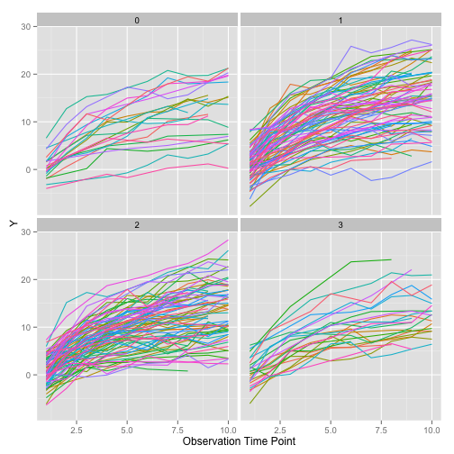

### Spaghetti plot with overall smoother

If you want a smoother for the overall group in addition to the spaghetti plot, you can just add `geom_smooth`:

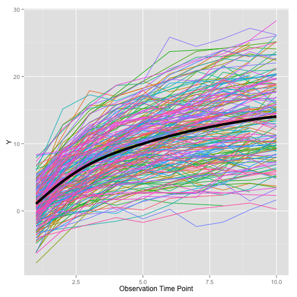

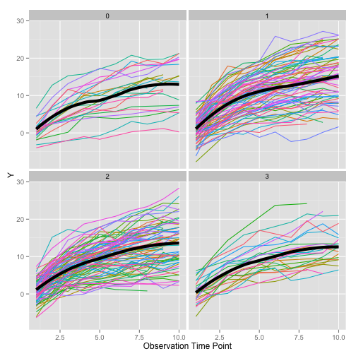

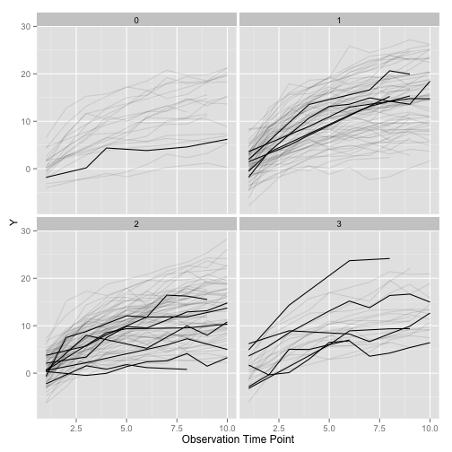

Note that the `group` aesthetic and `colour` aesthetic do not perform the same way for some operations. For example, let's try to smooth `bwswag`:

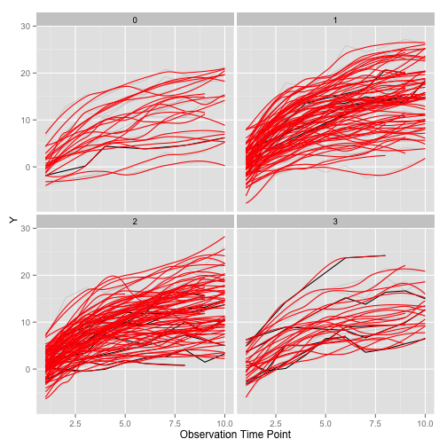

We see that it smooths each id, which is not what we want. We can achieve the desired result by setting the `group` aesthetic:

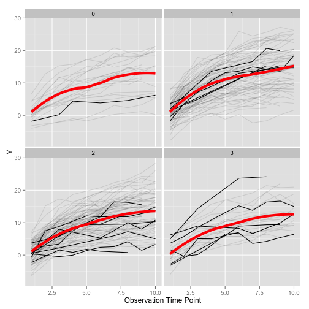

I hope that this demonstrates some of the simple yet powerful commands `ggplot2` allows users to execute. I agree that some behavior may not seem straightforward at first glance, but becomes more understandable as one uses `ggplot2` more.

## Another Case this is Useful - Save Plot Twice

Another (non-plotting) example I want to show is how saving `ggplot2` objects can make saving duplicate plots much easier. In many cases for making plots to show to others, I open up a PDF device using `pdf`, make a series of plots, and then close the PDF. There may be 1-2 plots that are the real punchline, and I want to make a high-res PNG of them separately. Let me be clear, I want both – the PDF and PNG. For example:

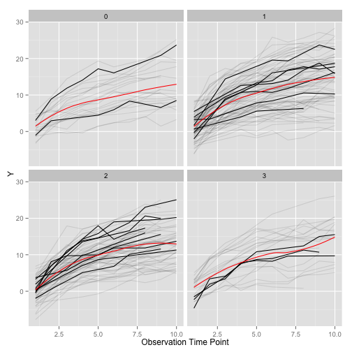

I am printing the objects, while assigning them. (I have to use the `{` brackets because I use `=` for assignment and `print` would evaluate that as arguments without `{}`). As `g2` is already saved as an object, I can close the PDF, open a `png` and then print that again.

No copying and pasting was needed for remaking the plot, nor some weird turning off and on devices.

## Conclusion

I (and think you should) use `ggplot2` for a lot of reasons, especially the grammar and philosphy. The plots I have used here are some powerful representations of data that are simple to execute. I believe using this system reflects and helps the true iterative process of making figures. The syntax may not seem intuitive to a long-time `R` user, but I believe the startup cost is worth the effort. Let me know if you'd like to see any other plots that you commonly use.